# assignment-4

Note: This is a modification of an optional assignment for course MUSA620. The original file included an outline for steps to perform.

Credit of designing this study: [Nick Hand](https://github.com/MUSA-620-Spring-2019).

## Exploring Yelp Reviews of Restaurants in Pittsburgh, PA

In this report, I will explore restaurant review data available through the [Yelp Dataset Challenge](https://www.yelp.com/dataset/challenge). The dataset includes Yelp data for user reviews and business information for 10 metropolitan areas. I chose Pittsburgh, PA for analysis.

This study is broken into two parts:

#### Part 1: testing how well sentiment analysis works.

Because Yelp reviews include the number of stars given by the user, the Yelp data set provides a unique opportunity to test how well our sentiment analysis works by comparing the number of stars to the polarity of reviews.

#### Part 2: analyzing correlations between restaurant reviews and census data

I'll explore geographic trends in the restaurant reviews, comparing the sentiment analysis results with user stars geographically. I'll also overlay review stars on maps of household income (using census data).

#### Background readings

- [Does sentiment analysis work?](http://varianceexplained.org/r/yelp-sentiment/)
- [The Geography of Taste: Using Yelp to Study Urban Culture](https://www.mdpi.com/2220-9964/7/9/376/pdf/1)

## 1. Does Sentiment Analysis Work?

### 1.1 Load review data

**Notes**

The JSON data is in a "records" format. To load it, you'll need to pass the following keywords:

- `orient='records'`
- `lines=True`

```python
import pandas as pd
```

```python
reviews_pitts = pd.read_json(path_or_buf = 'data/reviews_pittsburgh.json', orient = 'records', lines = True)
```

### 1.2 Format the review text

The first step is to split the review text into its individual words and make all of the words lower-cased.

Add a new column, called 'formatted_text', which each entry is a list of the lower-cased words in a review.

```python
reviews_pitts.head()
```

|  | business_id | review_id | stars | text |
| --- | --- | --- | --- | --- |
| 0 | eU_713ec6fTGNO4BegRaww | fdiNeiN_hoCxCMy2wTRW9g | 4 | I'll be the first to admit that I was not exci... |
| 1 | FxLfqxdYPA6Z85PFKaqLrg | Z7wgXp98wYB57QdRY3HQ3w | 4 | Wow. So surprised at the one and two star revi... |
| 2 | 9nTF596jDvBBia2EXXiOOg | 1daGBpea0sleayFeeXuoYw | 1 | if i can give this place no stars i would, i o... |
| 3 | sMzNLdhJZGzYirIWt-fMAg | RLbWoIri29BcQ8yjzsvQLQ | 5 | This place epitomizes the rumored transformati... |
| 4 | hcFSc0OHgZJybnjQBrL_8Q | vAckaF8n0KKJeqHOnb1ayw | 4 | Here's why I don't write reviews for Chinese r... |

```python
len(reviews_pitts)
```

```
162104
```

```python
reviews_pitts['formatted_text'] = reviews_pitts['text'].apply(lambda x: x.lower().split())
```

```python
reviews_pitts.head()
```

|  | business_id | review_id | stars | text | formatted_text |
| --- | --- | --- | --- | --- | --- |
| 0 | eU_713ec6fTGNO4BegRaww | fdiNeiN_hoCxCMy2wTRW9g | 4 | I'll be the first to admit that I was not exci... | [i'll, be, the, first, to, admit, that, i, was... |
| 1 | FxLfqxdYPA6Z85PFKaqLrg | Z7wgXp98wYB57QdRY3HQ3w | 4 | Wow. So surprised at the one and two star revi... | [wow., so, surprised, at, the, one, and, two, ... |
| 2 | 9nTF596jDvBBia2EXXiOOg | 1daGBpea0sleayFeeXuoYw | 1 | if i can give this place no stars i would, i o... | [if, i, can, give, this, place, no, stars, i, ... |
| 3 | sMzNLdhJZGzYirIWt-fMAg | RLbWoIri29BcQ8yjzsvQLQ | 5 | This place epitomizes the rumored transformati... | [this, place, epitomizes, the, rumored, transf... |
| 4 | hcFSc0OHgZJybnjQBrL_8Q | vAckaF8n0KKJeqHOnb1ayw | 4 | Here's why I don't write reviews for Chinese r... | [here's, why, i, don't, write, reviews, for, c... |

### 1.3 Review stop words

Use the `nltk` library to remove any stop words from the list of words in each review.

Overwrite the 'formatted_text' column to contain a list of lower-cased words in each review, with no stop words.

```python
import nltk
nltk.download('stopwords')
```

```
True
```

```python
stop_words = set(nltk.corpus.stopwords.words('english'))
```

```python
part_reviews = reviews_pitts
```

```python
pd.options.mode.chained_assignment = None  # to avoid unnecessary warning
```

```python
def filterstopwords(row):
    a = [word for word in row if word not in stop_words]
    return a
```

```python
part_reviews['formatted_text'] = part_reviews['formatted_text'].apply(filterstopwords)
```

```python
part_reviews.head() #line 4 is clearly different from the earlier table
```

|  | business_id | review_id | stars | text | formatted_text |
| --- | --- | --- | --- | --- | --- |
| 0 | eU_713ec6fTGNO4BegRaww | fdiNeiN_hoCxCMy2wTRW9g | 4 | I'll be the first to admit that I was not exci... | [i'll, first, admit, excited, going, la, tavol... |
| 1 | FxLfqxdYPA6Z85PFKaqLrg | Z7wgXp98wYB57QdRY3HQ3w | 4 | Wow. So surprised at the one and two star revi... | [wow., surprised, one, two, star, reviews!, st... |
| 2 | 9nTF596jDvBBia2EXXiOOg | 1daGBpea0sleayFeeXuoYw | 1 | if i can give this place no stars i would, i o... | [give, place, stars, would,, hot, pot, though,... |
| 3 | sMzNLdhJZGzYirIWt-fMAg | RLbWoIri29BcQ8yjzsvQLQ | 5 | This place epitomizes the rumored transformati... | [place, epitomizes, rumored, transformation, p... |
| 4 | hcFSc0OHgZJybnjQBrL_8Q | vAckaF8n0KKJeqHOnb1ayw | 4 | Here's why I don't write reviews for Chinese r... | [here's, write, reviews, chinese, restaurants:... |

### 1.4 Calculate polarity and subjectivity

Using the formatted text column, create a list of `textblob.TextBlob()` objects and then extract the `subjectivity` and `polarity`.

Add two new columns to the review DataFrame: `polarity` and `subjectivity`.

```python
import textblob
```

```python
formatted = [None]*len(part_reviews)
for i in range(len(part_reviews)):
    formatted[i] = ''.join(str(x)+' ' for x in part_reviews.loc[i]['formatted_text'])
```

```python
formatted[0]
```

```
'i\'ll first admit excited going la tavolta. food snob, group friends suggested go dinner looked online menu nothing special seemed overpriced. im also big ordering pasta go out. alas, outnumbered. thank goodness! ordered sea bass special. die for. cooked perfectly, seasoned perfectly, perfect porti…
```

```python
blobs = [textblob.TextBlob(r) for r in formatted]
```

```python
part_reviews['polarity'] = [b.sentiment.polarity for b in blobs]
part_reviews['subjectivity'] = [b.sentiment.subjectivity for b in blobs]
```

```python
part_reviews.head()
```

|  | business_id | review_id | stars | text | formatted_text | polarity | subjectivity |
| --- | --- | --- | --- | --- | --- | --- | --- |
| 0 | eU_713ec6fTGNO4BegRaww | fdiNeiN_hoCxCMy2wTRW9g | 4 | I'll be the first to admit that I was not exci... | [i'll, first, admit, excited, going, la, tavol... | 0.245505 | 0.609437 |
| 1 | FxLfqxdYPA6Z85PFKaqLrg | Z7wgXp98wYB57QdRY3HQ3w | 4 | Wow. So surprised at the one and two star revi... | [wow., surprised, one, two, star, reviews!, st... | 0.597787 | 0.818427 |
| 2 | 9nTF596jDvBBia2EXXiOOg | 1daGBpea0sleayFeeXuoYw | 1 | if i can give this place no stars i would, i o... | [give, place, stars, would,, hot, pot, though,... | 0.053869 | 0.664137 |
| 3 | sMzNLdhJZGzYirIWt-fMAg | RLbWoIri29BcQ8yjzsvQLQ | 5 | This place epitomizes the rumored transformati... | [place, epitomizes, rumored, transformation, p... | 0.266667 | 0.416667 |
| 4 | hcFSc0OHgZJybnjQBrL_8Q | vAckaF8n0KKJeqHOnb1ayw | 4 | Here's why I don't write reviews for Chinese r... | [here's, write, reviews, chinese, restaurants:... | 0.227083 | 0.557576 |

### 1.5 Comparing the sentiment analysis to number of stars

Use `seaborn` to make two box plots, one showing the polarity vs number of user stars and one showing the subjectivity vs the number of user stars.

```python
import seaborn as sns
```

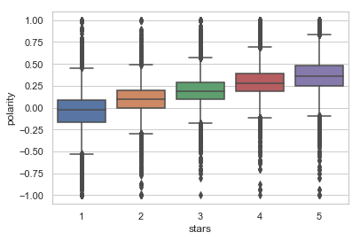

```python
sns.set(style = 'whitegrid')

ax1 = sns.boxplot(x='stars',y='polarity',data=part_reviews)
```

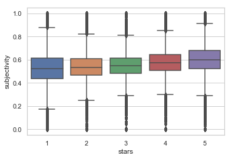

```python
ax2 = sns.boxplot(x='stars', y = 'subjectivity', data = part_reviews)
```

**Question:** What do your charts indicate for the effectiveness of our sentiment analysis?

The two charts above indicate that sentiment analysis is effective to a certain extent. The boxes are comparatively short in both charts, which means that most reviews with the same star have similar degrees of polarity and subjectivity. From the chart polarity vs. stars, the average level of polarity in each group increases as the restaurants are more positively reviewed. Whiskers for boxes of 1 star are high for both charts as well.

### 1.6 The importance of individual words

In this part, we'll explore the importance and frequency of individual words in Yelp reviews.

We will identify the most common reviews and then plot the average polarity vs the user stars for the reviews where those words occur.

#### 1.6.1 Select a random sample of the review data

Select 1,000 random rows from the DataFrame holding the review data. Use the `.sample()` function to perform the selection.

```python
rand_reviews = part_reviews.sample(1000)
```

#### 1.6.2 Re-format the data

Pass the subset of review data from the previous part to the `reshape_data()` function defined below. Explore the result of this function, and in one or two sentences, explain the operation performed by `reshape_data()`.

```python
def reshape_data(review_subset):
    """
    Reshape the input dataframe of review data.
    """
    from pandas import Series, merge

    X = (review_subset['formatted_text']
         .apply(Series)
         .stack()
         .reset_index(level=1, drop=True)
         .to_frame('word'))


    R = review_subset[['polarity', 'stars', 'review_id']]

    return merge(R, X, left_index=True, right_index=True).reset_index(drop=True)
```

```python
reshaped = reshape_data(rand_reviews)
```

```python
reshaped.head()
```

|  | polarity | stars | review_id | word |
| --- | --- | --- | --- | --- |
| 0 | 0.32 | 5 | XpRYSUBnKcomM2YmItmFYQ | absolutely |
| 1 | 0.32 | 5 | XpRYSUBnKcomM2YmItmFYQ | negatives. |
| 2 | 0.32 | 5 | XpRYSUBnKcomM2YmItmFYQ | great |
| 3 | 0.32 | 5 | XpRYSUBnKcomM2YmItmFYQ | service, |
| 4 | 0.32 | 5 | XpRYSUBnKcomM2YmItmFYQ | great |

**Question:** what is the operation performed by the `reshape_data()` function?

Create a new dataframe that has each word in each review with the corresponding polarity, stars and review_id. It is done by first extracting each word in each review to form new rows, whose index is set according to which review it belonged to. Then the dataframe of single words is merged with the original dataset according to the number of review.

#### 1.6.3 Calculate the average number of stars and polarity for each word

Using the result from 1.6.2, group by the "word" column, and calculate the following three quantities:

1. the size of each group
2. the average number of user stars for each word
3. the average polarity for each word

Combine these three results into a single DataFrame object.

**Hint:** you can combine the three results using either the `pandas.concat()` or the `pandas.merge()` function.

```python
groupedby = reshaped.groupby('word').agg({'review_id':'size','polarity':'mean','stars':'mean'}).reset_index()
```

```python
groupedby.columns = ['word','count','polarity','stars']
```

```python
groupedby.head()
```

|  | word | count | polarity | stars |
| --- | --- | --- | --- | --- |
| 0 | ! | 5 | 0.182088 | 3.8 |
| 1 | !! | 5 | 0.312309 | 4.2 |
| 2 | !!! | 4 | 0.224572 | 3.0 |
| 3 | !!!!! | 2 | 0.199602 | 3.0 |
| 4 | " | 4 | 0.260124 | 4.0 |

#### 1.6.4 Select words the occur at least 50 times in reviews

Trim your DataFrame from the last section to only include words that occurred at least 50 times. Remember, when you grouped by the 'word' column, the `size()` function told you how many times each word occurred.

```python
trimmed = groupedby.loc[groupedby['count']>=50]
```

```python
trimmed.head()
```

|  | word | count | polarity | stars |
| --- | --- | --- | --- | --- |
| 282 | & | 84 | 0.219813 | 3.797619 |
| 564 | - | 241 | 0.213838 | 3.568465 |
| 659 | 2 | 69 | 0.127716 | 2.623188 |
| 932 | actually | 56 | 0.165905 | 3.071429 |
| 1113 | almost | 55 | 0.163039 | 3.400000 |

#### 1.6.5 Plot the average polarity vs user stars

Use `matplotlib` to make a scatter plot of the average user stars vs average polarity for the words in the data frame from the last section. This will involve two steps:

Loop over each row of the data frame from the last section and for each row:

1. Use `plt.scatter(x, y)` to plot a scatter plot, where x is polarity and y is stars.
2. Use `plt.text(x, y, word)` to add the corresponding word to each scatter marker.

Using the data frame from section 1.4, add vertical and horizontal lines to your chart that shows the average number of user stars and the average polarity across all reviews in the data set.

Make sure the figure is big enough so that you can make out some of the words, especially at low and high polarity values. You should be able to see a strong trend between polarity and user stars, and some of the most common words occurring in these reviews.

```python
import matplotlib
from matplotlib import pyplot as plt
from matplotlib.pyplot import figure
```

```python
trimmed = trimmed.reset_index()
```

```python
trimmed.head()
```

|  | index | word | count | polarity | stars |
| --- | --- | --- | --- | --- | --- |
| 0 | 282 | & | 84 | 0.219813 | 3.797619 |
| 1 | 564 | - | 241 | 0.213838 | 3.568465 |
| 2 | 659 | 2 | 69 | 0.127716 | 2.623188 |
| 3 | 932 | actually | 56 | 0.165905 | 3.071429 |
| 4 | 1113 | almost | 55 | 0.163039 | 3.400000 |

```python
a = part_reviews['polarity'].mean()
b = part_reviews['stars'].mean()
```

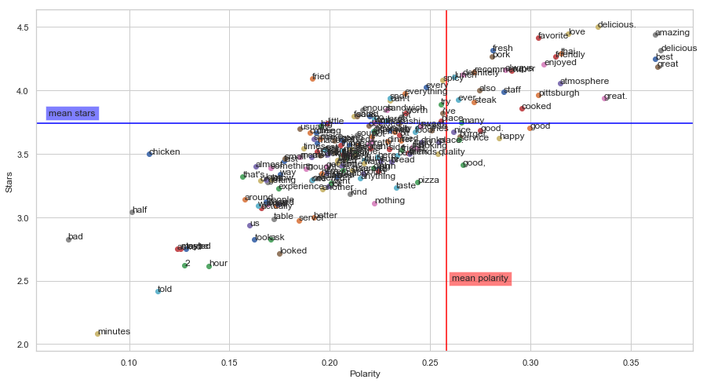

```python
plt.figure(figsize=(15,8))
plt.axvline(a,color='red')
plt.axhline(b,color='blue')
plt.xlabel('Polarity')
plt.ylabel('Stars')
plt.text(x=a+0.003,y=2.5,s='mean polarity',bbox=dict(facecolor='red', alpha=0.5))
plt.text(x=0.06,y=b+0.06,s='mean stars',bbox=dict(facecolor='blue', alpha=0.5))

for i in range(len(trimmed)):
    plt.scatter(x=trimmed.loc[i]['polarity'],y=trimmed.loc[i]['stars'])
    plt.text(x=trimmed.loc[i]['polarity'],y=trimmed.loc[i]['stars'],s=trimmed.loc[i]['word'])
```

## 2. Correlating restaurant data and household income

In this part, we'll use the census API to download household income data and overlay restaurant locations.

### 2.1 Query the Census API

Use the `census_area` package to download total household income by census tract (with tract geometries) from the 2017 ACS data set. You can identify the proper variable name from:

https://api.census.gov/data/2017/acs/acs5/variables.html

**Hints**

The FIPS codes for the various cities are:

- Pittsburgh
  - PA code: '42'
  - City code: '61000'
- Cleveland
  - OH code: '39'
  - City code: '16000'
- Charlotte
  - NC code: '37'
  - City code: '12000'

```python
from census_area import Census
```

```python
api_key = "51a775979b7e8be111c120dca85b7ce106eb26d2"
c = Census(key=api_key)
```

```python
state_code = '42'
city_code = '61000'
```

```python
variables = ('NAME', 'B19001_001E')
tracts = c.acs5.state_place_tract(variables, state_code,
                                      city_code, year=2017,
                                      return_geometry=True)
```

### 2.2 Convert the GeoJSON features to a GeoDataFrame

Be sure to use the proper CRS for census data.

```python
import geopandas as gpd
```

```python
crs = {'init':'epsg:4269'}
hhgdf = gpd.GeoDataFrame.from_features(tracts, crs=crs)
```

```python
hhgdf.head()
```

|  | AREALAND | AREAWATER | B19001_001E | BASENAME | CENTLAT | CENTLON | COUNTY | FUNCSTAT | GEOID | INTPTLAT | ... | OBJECTID | OID | STATE | STGEOMETRY.AREA | STGEOMETRY.LEN | TRACT | county | geometry | state | tract |
| --- | --- | --- | --- | --- | --- | --- | --- | --- | --- | --- | --- | --- | --- | --- | --- | --- | --- | --- | --- | --- | --- |
| 0 | 881779 | 0 | 1156.0 | 2022 | +40.4540547 | -080.0636247 | 003 | S | 42003202200 | +40.4540547 | ... | 2935 | 20755321756903 | 42 | 1.524536e+06 | 6649.036020 | 202200 | 003 | POLYGON ((-80.07199799999999 40.453356, -80.07... | 42 | 202200 |
| 1 | 2532255 | 0 | 1909.0 | 2023 | +40.4103004 | -080.0392970 | 003 | S | 42003202300 | +40.4103004 | ... | 6831 | 20755321756928 | 42 | 4.372478e+06 | 10137.272451 | 202300 | 003 | POLYGON ((-80.051202 40.401943, -80.050837 40.... | 42 | 202300 |
| 2 | 1328964 | 0 | 1082.0 | 2814 | +40.4471360 | -080.0519580 | 003 | S | 42003281400 | +40.4471360 | ... | 60097 | 20755321757016 | 42 | 2.297229e+06 | 6346.953399 | 281400 | 003 | POLYGON ((-80.06283999999999 40.448545, -80.06... | 42 | 281400 |
| 3 | 617106 | 0 | 674.0 | 2815 | +40.4404623 | -080.0539288 | 003 | S | 42003281500 | +40.4404623 | ... | 27369 | 20755321757037 | 42 | 1.066508e+06 | 4669.731854 | 281500 | 003 | POLYGON ((-80.061216 40.440632, -80.061133 40.... | 42 | 281500 |
| 4 | 1453893 | 0 | 1778.0 | 2902 | +40.3993660 | -079.9838310 | 003 | S | 42003290200 | +40.3993660 | ... | 27370 | 20755321757060 | 42 | 2.509650e+06 | 8376.186094 | 290200 | 003 | POLYGON ((-79.992332 40.406587, -79.992323 40.... | 42 | 290200 |

5 rows × 24 columns

## 2.3 Plot a choropleth map of the household income

Use the built-in `geopandas` `plot()` function.

Be sure to convert to a reasonable CRS first!

```python
%matplotlib inline
```

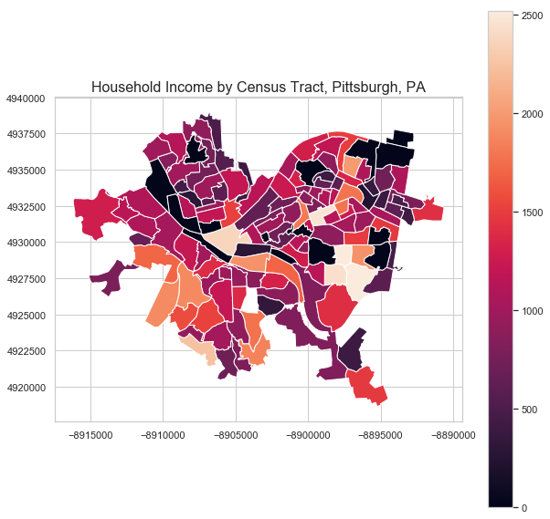

```python
ax = hhgdf.to_crs(epsg=3857).plot(column='B19001_001E', legend=True)

ax.set_title("Household Income by Census Tract, Pittsburgh, PA", fontsize=16)
ax.figure.set_size_inches((10,10))
```

## 2.4 Load the restaurants data

Use the `latitude` and `longitude` columns to create a GeoDataFrame after loading the JSON data.

**Notes**

The JSON data is in a "records" format. To load it, you'll need to pass the following keywords:

- `orient='records'`
- `lines=True`

```python
restaurants_pitts = pd.read_json(path_or_buf = 'data/restaurants_pittsburgh.json', orient = 'records', lines = True)
```

```python
restaurants_pitts.head()
```

|  | business_id | latitude | longitude | name | review_count | stars |
| --- | --- | --- | --- | --- | --- | --- |
| 0 | 1RHY4K3BD22FK7Cfftn8Mg | 40.496177 | -80.246011 | Marathon Diner | 35 | 4.0 |
| 1 | dQj5DLZjeDK3KFysh1SYOQ | 40.465694 | -79.949324 | Apteka | 242 | 4.5 |
| 2 | v-scZMU6jhnmV955RSzGJw | 40.441062 | -80.002126 | No. 1 Sushi Sushi | 106 | 4.5 |
| 3 | t-6tdxRaz7s9a0sf94Tguw | 40.462345 | -79.924165 | Impressionz | 29 | 4.5 |
| 4 | 5WMIvoMx3l1vn1uJ3HZB6Q | 40.442863 | -79.996412 | Subway | 3 | 3.0 |

```python
restaurants_pitts['coord'] = list(zip(restaurants_pitts['longitude'],restaurants_pitts['latitude']))
```

```python
from shapely.geometry import Point
restaurants_pitts['coord'] = restaurants_pitts['coord'].apply(Point)
```

```python
restaurants_pitts.head()
```

|  | business_id | latitude | longitude | name | review_count | stars | coord |
| --- | --- | --- | --- | --- | --- | --- | --- |
| 0 | 1RHY4K3BD22FK7Cfftn8Mg | 40.496177 | -80.246011 | Marathon Diner | 35 | 4.0 | POINT (-80.24601123639999 40.4961769456) |
| 1 | dQj5DLZjeDK3KFysh1SYOQ | 40.465694 | -79.949324 | Apteka | 242 | 4.5 | POINT (-79.9493238 40.4656937) |
| 2 | v-scZMU6jhnmV955RSzGJw | 40.441062 | -80.002126 | No. 1 Sushi Sushi | 106 | 4.5 | POINT (-80.002126 40.441062) |
| 3 | t-6tdxRaz7s9a0sf94Tguw | 40.462345 | -79.924165 | Impressionz | 29 | 4.5 | POINT (-79.92416515950001 40.4623454064) |
| 4 | 5WMIvoMx3l1vn1uJ3HZB6Q | 40.442863 | -79.996412 | Subway | 3 | 3.0 | POINT (-79.99641200000001 40.4428627) |

```python
pitts = gpd.GeoDataFrame(restaurants_pitts, geometry = 'coord')
```

```python
pitts.crs = crs
```

## 2.5 Overlay restaurants on the income map

Overlay the restaurants and color the points according to the 'stars' column.

You can use the 'coolwarm' color map: blue points will have below-average reviews and red points will have above-average stars.

**Hint**

You can use the `.geometry.total_bounds` attribute to get the axes limits of the city's census tracts.

```
[xmin, ymin, xmax, ymax] = income.geometry.total_bounds
```

You can then use these limits to set the matplotlib plot limits accordingly.

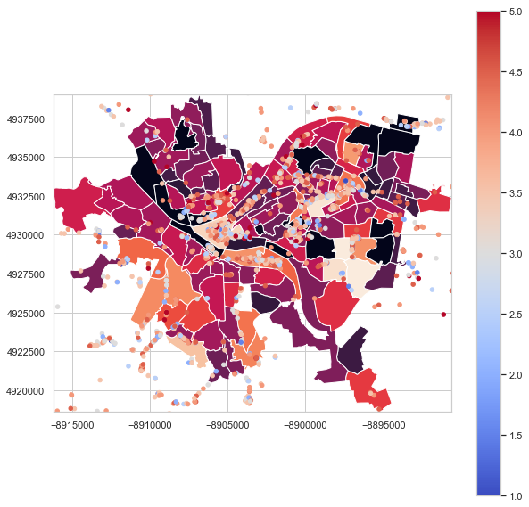

```python
[xmin, ymin, xmax, ymax] = hhgdf.to_crs(epsg=3857).geometry.total_bounds

ax1 = hhgdf.to_crs(epsg=3857).plot(column='B19001_001E')

ax2 = pitts.to_crs(epsg=3857).plot(column='stars',markersize = 20, cmap = 'coolwarm',ax = ax1, legend = True)

ax2.set_xlim(xmin, xmax)
ax2.set_ylim(ymin, ymax)

ax2.figure.set_size_inches((10,10))
```

## 2.6 Comparing polarity vs. stars geographically

- Merge the restaurants GeoDataFrame with the DataFrame with the 'polarity' column for each review.
- Make a side-by-side plot with two columns: one subplot shows hex bins giving the polarity of the restaurant review and the other shows hex bins giving the number of stars

As we saw in Section 1, you should see strong correlation between the two subplots.

**Hints**

- The 'business_id' column should be present in both the data frames holding review data and restaurant data.
- See the `plt.subplots()` function for creating a figure with 2 subplots.

```python
pitts.head()
```

|  | business_id | latitude | longitude | name | review_count | stars | coord |
| --- | --- | --- | --- | --- | --- | --- | --- |
| 0 | 1RHY4K3BD22FK7Cfftn8Mg | 40.496177 | -80.246011 | Marathon Diner | 35 | 4.0 | POINT (-80.24601123639999 40.4961769456) |
| 1 | dQj5DLZjeDK3KFysh1SYOQ | 40.465694 | -79.949324 | Apteka | 242 | 4.5 | POINT (-79.9493238 40.4656937) |
| 2 | v-scZMU6jhnmV955RSzGJw | 40.441062 | -80.002126 | No. 1 Sushi Sushi | 106 | 4.5 | POINT (-80.002126 40.441062) |
| 3 | t-6tdxRaz7s9a0sf94Tguw | 40.462345 | -79.924165 | Impressionz | 29 | 4.5 | POINT (-79.92416515950001 40.4623454064) |
| 4 | 5WMIvoMx3l1vn1uJ3HZB6Q | 40.442863 | -79.996412 | Subway | 3 | 3.0 | POINT (-79.99641200000001 40.4428627) |

```python
merged = pitts.merge(part_reviews,left_on='business_id', right_on='business_id')
merged.head()
```

|  | business_id | latitude | longitude | name | review_count | stars_x | coord | review_id | stars_y | text | formatted_text | polarity | subjectivity |
| --- | --- | --- | --- | --- | --- | --- | --- | --- | --- | --- | --- | --- | --- |
| 0 | 1RHY4K3BD22FK7Cfftn8Mg | 40.496177 | -80.246011 | Marathon Diner | 35 | 4.0 | POINT (-80.24601123639999 40.4961769456) | PaPQzyr6chg_eo_u4mw0Dw | 5 | Marathon Diner may not look fancy, but I had t... | [marathon, diner, may, look, fancy,, best, air... | 0.311607 | 0.590516 |
| 1 | 1RHY4K3BD22FK7Cfftn8Mg | 40.496177 | -80.246011 | Marathon Diner | 35 | 4.0 | POINT (-80.24601123639999 40.4961769456) | hpV7n-LmphR56l3YKVshiw | 2 | What a ripoff. For a $13 salad all you get is ... | [ripoff., $13, salad, get, iceberg, lettuce,, ... | 0.133333 | 0.516667 |
| 2 | 1RHY4K3BD22FK7Cfftn8Mg | 40.496177 | -80.246011 | Marathon Diner | 35 | 4.0 | POINT (-80.24601123639999 40.4961769456) | MPmKK0e8zuOjjae2hr-YJg | 5 | This experience was a joy. The food was great.... | [experience, joy., food, great., service, grea... | 0.428571 | 0.478571 |
| 3 | 1RHY4K3BD22FK7Cfftn8Mg | 40.496177 | -80.246011 | Marathon Diner | 35 | 4.0 | POINT (-80.24601123639999 40.4961769456) | EJDXWWLfY3bWI-b4K1Bnxw | 1 | The one at the airport is just ... bad the ser... | [one, airport, ..., bad, servers, bored, attit... | -0.450000 | 0.688889 |
| 4 | 1RHY4K3BD22FK7Cfftn8Mg | 40.496177 | -80.246011 | Marathon Diner | 35 | 4.0 | POINT (-80.24601123639999 40.4961769456) | J9569hRV3zEWoYHosHZ6AA | 5 | Had an early flight and wife and I were hungr... | [early, flight, wife, hungry., noticed, marath... | 0.366667 | 0.350000 |

```python
mg = merged.groupby(['business_id'])['polarity'].mean().reset_index()
```

```python
mg.head()
```

|  | business_id | polarity |
| --- | --- | --- |
| 0 | --ujyvoQlwVoBgMYtADiLA | 0.302486 |
| 1 | -1xCh7Cocn6IwFzhELyohA | 0.190149 |
| 2 | -3rvpkYkYD_N1IP4hSvD0A | 0.178506 |
| 3 | -40RDS4F54qiGiEQUsZaXA | 0.356283 |
| 4 | -7H-oXvCxJzuT42ky6Db0g | 0.236090 |

```python
mgl = pitts.merge(mg, left_on = 'business_id', right_on = 'business_id')
```

```python
mgl.head()
```

|  | business_id | latitude | longitude | name | review_count | stars | coord | polarity |
| --- | --- | --- | --- | --- | --- | --- | --- | --- |
| 0 | 1RHY4K3BD22FK7Cfftn8Mg | 40.496177 | -80.246011 | Marathon Diner | 35 | 4.0 | POINT (-80.24601123639999 40.4961769456) | 0.257575 |
| 1 | dQj5DLZjeDK3KFysh1SYOQ | 40.465694 | -79.949324 | Apteka | 242 | 4.5 | POINT (-79.9493238 40.4656937) | 0.330375 |
| 2 | v-scZMU6jhnmV955RSzGJw | 40.441062 | -80.002126 | No. 1 Sushi Sushi | 106 | 4.5 | POINT (-80.002126 40.441062) | 0.325628 |
| 3 | t-6tdxRaz7s9a0sf94Tguw | 40.462345 | -79.924165 | Impressionz | 29 | 4.5 | POINT (-79.92416515950001 40.4623454064) | 0.237149 |
| 4 | 5WMIvoMx3l1vn1uJ3HZB6Q | 40.442863 | -79.996412 | Subway | 3 | 3.0 | POINT (-79.99641200000001 40.4428627) | 0.029696 |

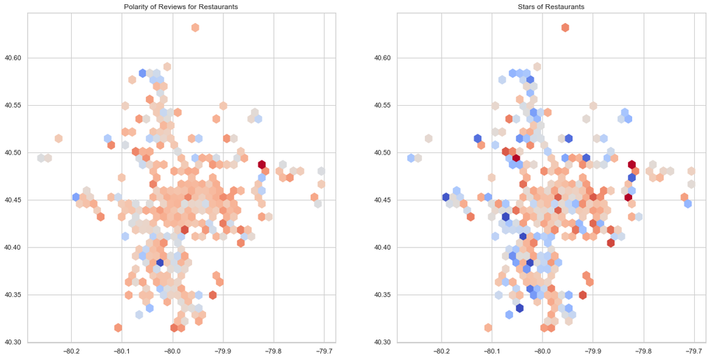

```python
[xmin, ymin, xmax, ymax] = hhgdf.to_crs(epsg=3857).geometry.total_bounds
fig = plt.figure()
fig.set_figheight(10)
fig.set_figwidth(20)

# fig, ax = plt.subplots(ncols=2, figsize=(18,18))
ax3 = fig.add_subplot(1,2,1)
plt.hexbin(merged.geometry.x, merged.geometry.y, C = merged['polarity'], gridsize=40, mincnt=1, cmap='coolwarm')
ax3.set_title('Polarity of Reviews for Restaurants')


ax4 = fig.add_subplot(1,2,2)
plt.hexbin(merged.geometry.x, merged.geometry.y, C = merged['stars_y'], gridsize=40, mincnt=1, cmap='coolwarm')
ax4.set_title('Stars of Restaurants')
```